# 세종대왕의 세법개혁과 세법개혁에 대한 국민투표

성이다르조

2015년 11월 18일

## 목 차

### 서론

#### 연구목적

### 본론

#### 그래픽 분석

##### pie chart

##### bar plot & mosaicplot

##### gglot을 이용한 분석

### 결론

#### 결론

#### 참고 자료

### 서론

#### 연구목적

세종대왕의 조세사상을 먼저 살펴보고, 공법의 입법과 시행하는 과정에서의 특징을 살펴본 다음, 공법이 조선 500년 동안 ｢경국대전｣과 ｢속대전｣, ｢대전통편｣ 등의 전세법(田稅法)에 미치는 영향을 분석하고자 한다. 세종대왕이 입법한 공법을 조세법 측면 에서 연구하는 목적은 공법의 규정 및 공법 입법과정의 역사적 우수성을 재정립 할뿐만 아니라 학문적인 가치성을 세계화하는데 있다. 또한 세종대왕의 조세사상과 조세정책을 살펴봄으로써 오늘날 시시때때로 당리당락에 따라 원칙없이 바뀌는 조세법의 입법과 조세정책에 대한 올바른 원칙과 지침을 주고자 한다.

### 본론

#### 그래프 분석

①자료구조 원자료는 세종실록에서, 요약한 표는 오기수 교수님의 논문을 참고한 자료이다.

```r
sejong.poll<-read.table("sejong_poll.txt", header=TRUE,sep="")
str(sejong.poll)
```

```
## 'data.frame':    44 obs. of  4 variables:
##  $ counts: int  21 194 259 393 443 117 1123 71 29 5 ...
##  $ vote  : chr  "yes" "no" "yes" "no" ...
##  $ class : chr  "high" "high" "third.current" "third.current" ...
##  $ region: chr  "Seoul" "Seoul" "Seoul" "Seoul" ...
```

```r
sejong.poll
```

```
##    counts vote         class      region
## 1      21  yes          high       Seoul
## 2     194   no          high       Seoul
## 3     259  yes third.current       Seoul
## 4     393   no third.current       Seoul
## 5     443  yes      third.ex       Seoul
## 6     117   no      third.ex       Seoul
## 7    1123  yes      ordinary        yuhu
## 8      71   no      ordinary        yuhu
## 9      29  yes         chief     gyunggi
## 10      5   no         chief     gyunggi
## 11  17076  yes      ordinary     gyunggi
## 12    236   no      ordinary     gyunggi
## 13      1   no          high     pyungan
## 14      6  yes         chief     pyungan
```

[output cut: 30 more lines]

-불러온 원자료를 새로운 변수로 저장하고, 요인으로 투표,계급,지역이 필요하기 때문에 factor()를 사용하여 알파벳 순서에 따라 집계할 때 고려하는 부분에서 위험요소를 없앤다.

```r
sejong.poll.2<-sejong.poll

sejong.poll.2$vote<-factor(sejong.poll.2$vote, levels=c("yes","no"), labels=c("찬성","반대"))
sejong.poll.2$class<-factor(sejong.poll.2$class, levels=c("high","chief","third.current","third.ex","ordinary"), labels=c("대신 등","수령", "3품이하현직", "3품이하전직", "품관촌민"))
sejong.poll.2$region<-factor(sejong.poll.2$region, levels=c("Seoul","yuhu", "gyunggi", "pyungan", "hwanghae", "chungcheong", "kangwon", "hamgil", "gyungsang", "jeolla"),labels=c("서울","유후사","경기","평안","황해","충청","강원","함길","경상","전라"))
str(sejong.poll.2)
```

```
## 'data.frame':    44 obs. of  4 variables:
##  $ counts: int  21 194 259 393 443 117 1123 71 29 5 ...
##  $ vote  : Factor w/ 2 levels "찬성","반대": 1 2 1 2 1 2 1 2 1 2 ...
##  $ class : Factor w/ 5 levels "대신 등","수령",..: 1 1 3 3 4 4 5 5 2 2 ...
##  $ region: Factor w/ 10 levels "서울","유후사",..: 1 1 1 1 1 1 2 2 3 3 ...
```

```r
sejong.poll.2
```

```
##    counts vote       class region
## 1      21 찬성     대신 등   서울
## 2     194 반대     대신 등   서울
## 3     259 찬성 3품이하현직   서울
## 4     393 반대 3품이하현직   서울
## 5     443 찬성 3품이하전직   서울
## 6     117 반대 3품이하전직   서울
## 7    1123 찬성    품관촌민 유후사
## 8      71 반대    품관촌민 유후사
## 9      29 찬성        수령   경기
## 10      5 반대        수령   경기
## 11  17076 찬성    품관촌민   경기
## 12    236 반대    품관촌민   경기
## 13      1 반대     대신 등   평안
## 14      6 찬성        수령   평안
```

[output cut: 30 more lines]

-찬성과 반대의 색깔을 지정한다.

```r
sejong.poll.2$color[sejong.poll.2$vote=="찬성"]<-"blue"
sejong.poll.2$color[sejong.poll.2$vote=="반대"]<-"red"
```

## 그래프 그리기

우선, 전체 계급에 대한 찬반(여론조사)을 pie chart로 나타낸다.

```r
options(digits=3)
xtabs(counts~vote, data=sejong.poll.2)
```

```
## vote
##  찬성  반대
## 98657 74149
```

```r
prop.table(xtabs(counts~vote, data=sejong.poll.2))
```

```
## vote
##  찬성  반대
## 0.571 0.429
```

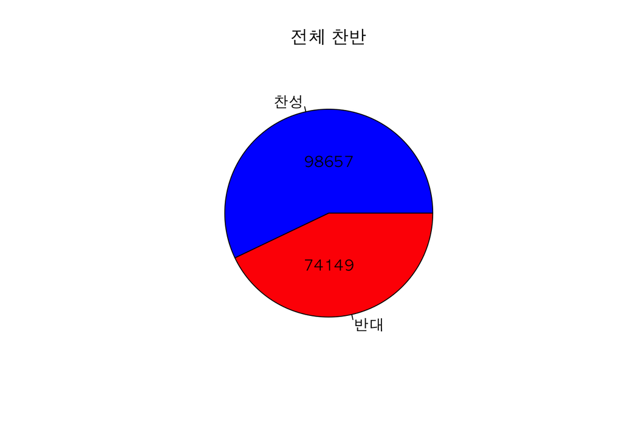

```r
pie(xtabs(counts~vote,data=sejong.poll.2),col=sejong.poll.2$color)
title(main="전체 찬반")
text(x=0, y=c(0.4,-0.4), labels=c("98657", "74149"))
```

-4개의 각 관료 인구수와 품관촌민 인구수가 월등히 차이가 나므로 관료집단과 품관촌민 두그룹으로 나눠서 pie chart를 그려보았다.

```r
xtabs(counts~vote+class, data=sejong.poll.2)
```

```
##       class
## vote   대신 등  수령 3품이하현직 3품이하전직 품관촌민
##   찬성      21   192         259         443    97742
##   반대     200   135         393         117    73304
```

```r
sejong.poll.2$class.2<-ifelse(sejong.poll.2$class=="품관촌민", "품관촌민", "관료집단")
str(sejong.poll.2)
```

```
## 'data.frame':    44 obs. of  6 variables:
##  $ counts : int  21 194 259 393 443 117 1123 71 29 5 ...
##  $ vote   : Factor w/ 2 levels "찬성","반대": 1 2 1 2 1 2 1 2 1 2 ...
##  $ class  : Factor w/ 5 levels "대신 등","수령",..: 1 1 3 3 4 4 5 5 2 2 ...
##  $ region : Factor w/ 10 levels "서울","유후사",..: 1 1 1 1 1 1 2 2 3 3 ...
##  $ color  : chr  "blue" "red" "blue" "red" ...
##  $ class.2: chr  "관료집단" "관료집단" "관료집단" "관료집단" ...
```

```r
sejong.poll.2$class.2<-factor(sejong.poll.2$class.2,levels=c("관료집단","품관촌민"),labels=c("관료집단","품관촌민"))
str(sejong.poll.2)
```

```
## 'data.frame':    44 obs. of  6 variables:
##  $ counts : int  21 194 259 393 443 117 1123 71 29 5 ...
##  $ vote   : Factor w/ 2 levels "찬성","반대": 1 2 1 2 1 2 1 2 1 2 ...
##  $ class  : Factor w/ 5 levels "대신 등","수령",..: 1 1 3 3 4 4 5 5 2 2 ...
##  $ region : Factor w/ 10 levels "서울","유후사",..: 1 1 1 1 1 1 2 2 3 3 ...
##  $ color  : chr  "blue" "red" "blue" "red" ...
##  $ class.2: Factor w/ 2 levels "관료집단","품관촌민": 1 1 1 1 1 1 2 2 1 1 ...
```

```r
xtabs(counts~vote+class.2, data=sejong.poll.2)
```

```
##       class.2
## vote   관료집단 품관촌민
##   찬성      915    97742
##   반대      845    73304
```

```r
addmargins(xtabs(counts~vote+class.2, data=sejong.poll.2))
```

```
##       class.2
## vote   관료집단 품관촌민    Sum
##   찬성      915    97742  98657
##   반대      845    73304  74149
##   Sum      1760   171046 172806
```

```r
prop.table(xtabs(counts~vote+class.2,data=sejong.poll.2), margin=2)
```

```
##       class.2
## vote   관료집단 품관촌민
##   찬성    0.520    0.571
##   반대    0.480    0.429
```

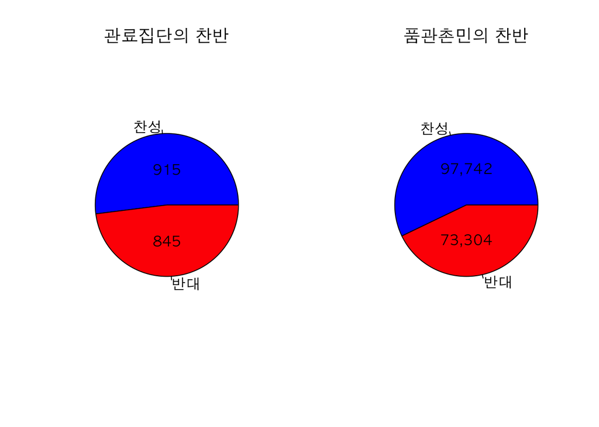

```r
attach(sejong.poll.2)
par(mfrow=c(1,2))
pie(xtabs(counts~vote+class.2,data=sejong.poll.2[class.2=="관료집단",], drop=T), labels=c("찬성", "반대"),col=color)
title(main="관료집단의 찬반")
text(x=0, y=c(0.4,-0.4), labels=c("915", "845"))
pie(xtabs(counts~vote+class.2,data=sejong.poll.2[class.2=="품관촌민",], drop=T), labels=c("찬성", "반대"),col=color)
title(main="품관촌민의 찬반")
text(x=0, y=c(0.4,-0.4), labels=c("97,742", "73,304"))
```

## 지역에 따른 관료와 서민의 각 여론조사결과

각 지역별 관료집단과 품관촌민의 찬반을 막대그래프로 나타낸다.

```r
par(mfrow=c(1,1))
xtabs(counts~vote+region,data=sejong.poll.2[class.2=="관료집단",], drop=T)
```

```
##       region
## vote   서울 경기 평안 황해 충청 강원 함길 경상 전라
##   찬성  723   29    6   17   35    5    3   55   42
##   반대  704    5   36   17   28   10   15   16   14
```

```r
xtabs(counts~vote+region,data=sejong.poll.2[class.2=="품관촌민",], drop=T)
```

```
##       region
## vote   유후사  경기  평안  황해  충청  강원  함길  경상  전라
##   찬성   1123 17076  1326  4454  6982   939    75 36262 29505
##   반대     71   236 28474 15601 14013  6888  7387   377   257
```

### 서울지역의 여론조사결과

- 서울은 다른 지역보다 월등히 많은 관료가 거주하므로 별도 집계하여, barplot과 mosaicplot으로 그려보았다.

```r
xtabs(counts~vote+class,data=sejong.poll.2[region=="서울",], drop=T)
```

```
##       class
## vote   대신 등 3품이하현직 3품이하전직
##   찬성      21         259         443
##   반대     194         393         117
```

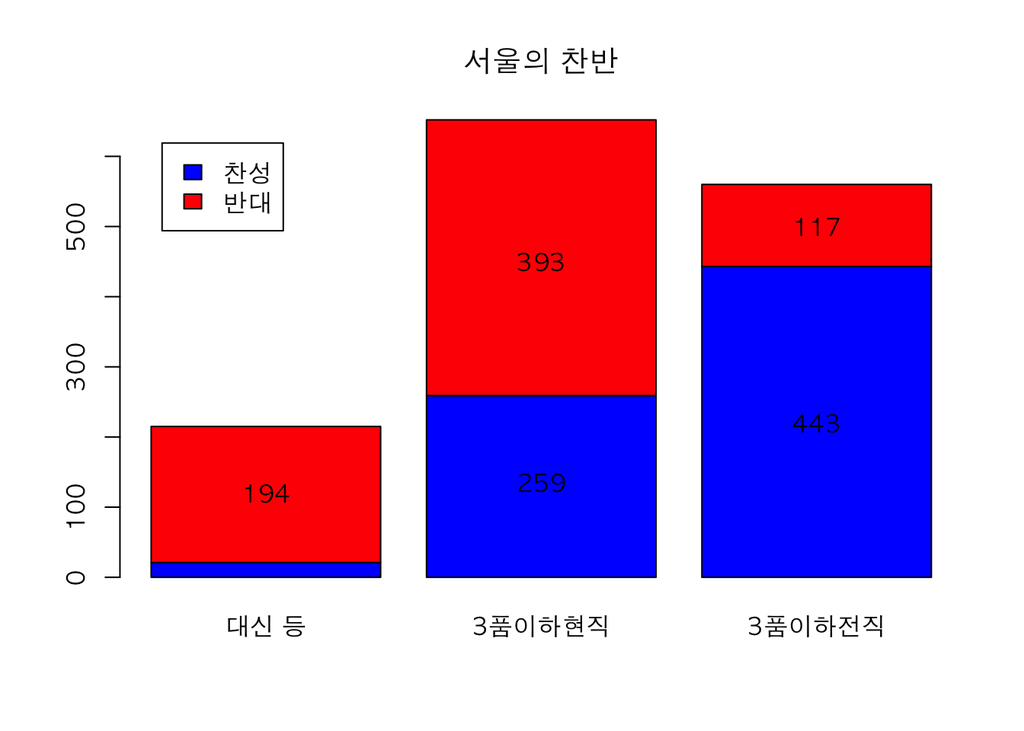

```r
barplot(xtabs(counts~vote+class,data=sejong.poll.2[region=="서울",], drop=T), col=color)
title(main="서울의 찬반")
text(x=c(0.7, 1.9, 1.9, 3.1, 3.1), y=c(120, 450, 135, 500, 220), labels=c("194","393", "259", "117", "443"))
legend("topleft",inset=0.05,fill=c("blue","red"),legend=c("찬성", "반대"))
```

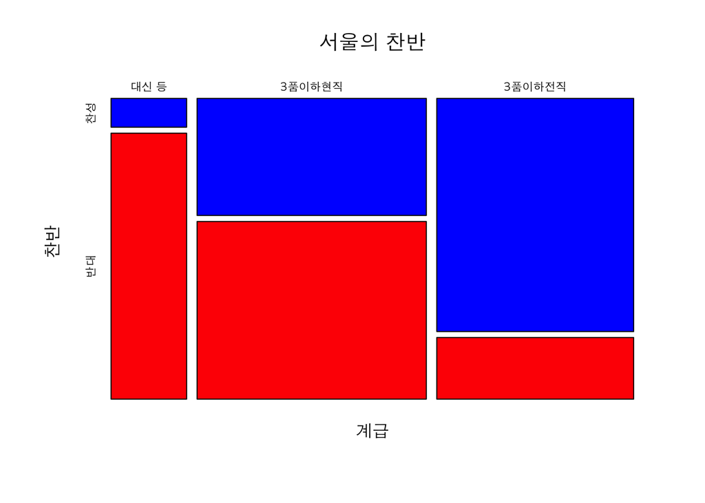

```r
mosaicplot(xtabs(counts~class+vote, data=sejong.poll.2[region=="서울",], drop=T), col=color, main="서울의 찬반", xlab="계급" , ylab ="찬반")
```

### 나머지 지역 관료집단의 여론조사결과

-서울지역을 제외한 지역별 관료집단의 찬반을 barplot과 mosaicplot으로 그려보았다.

```r
xtabs(counts~vote+region,data=sejong.poll.2[class.2=="관료집단" & !region=="서울",], drop=T)
```

```
##       region
## vote   경기 평안 황해 충청 강원 함길 경상 전라
##   찬성   29    6   17   35    5    3   55   42
##   반대    5   36   17   28   10   15   16   14
```

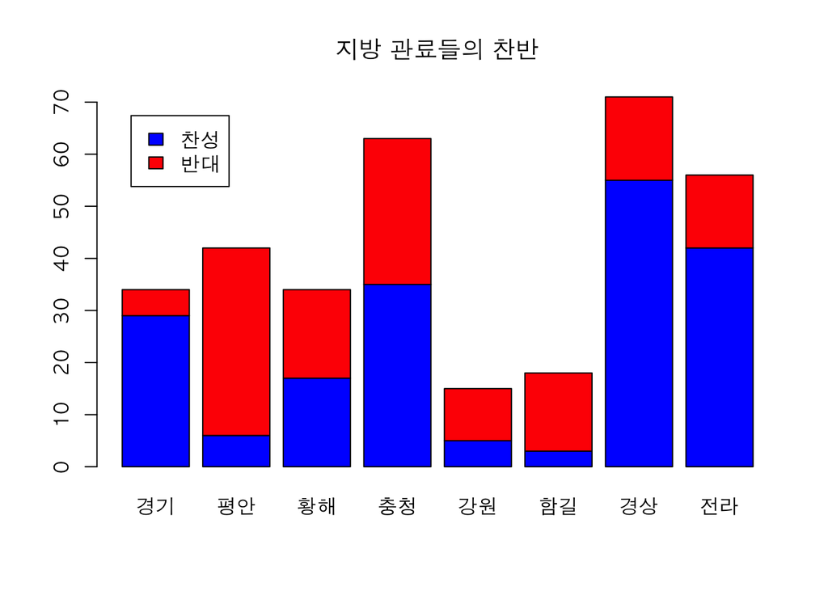

```r
barplot(xtabs(counts~vote+region, data=sejong.poll.2[class.2=="관료집단" & !region=="서울",], drop=T), col=color)
title(main="지방 관료들의 찬반")
legend("topleft", inset=0.05, fill=c("blue", "red"), legend=c("찬성", "반대"))
```

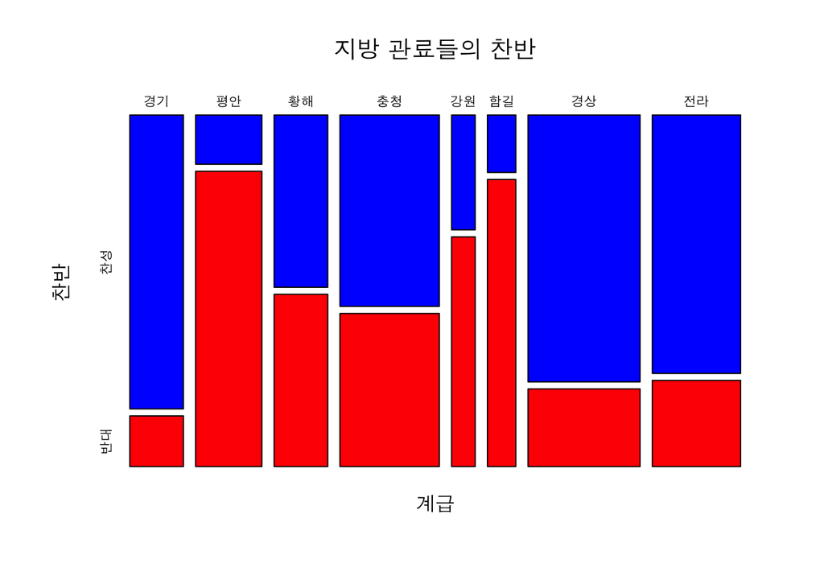

```r
mosaicplot(xtabs(counts~region+vote, data=sejong.poll.2[class.2=="관료집단" & !region=="서울",], drop=T), col=color, main="", xlab="계급", ylab="찬반")
title(main="지방 관료들의 찬반")
```

### 지역별 품관촌민의여론조사결과

- 품관촌민들의 지역별 찬반을 barplot과 mosaicplot으로 나타내었다.

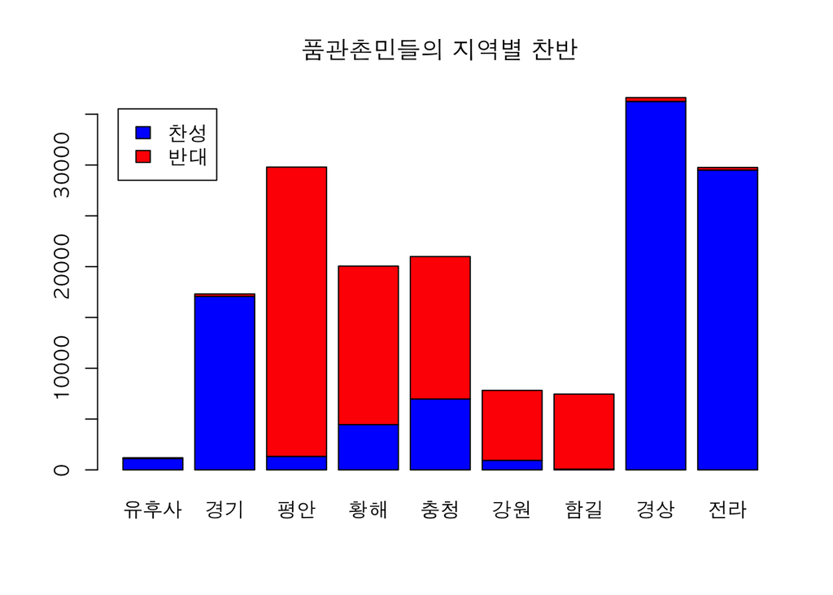

```r
barplot(xtabs(counts~vote+region, data=sejong.poll.2[class.2=="품관촌민",], drop=T), col=color)
title(main="품관촌민들의 지역별 찬반")
legend("topleft", inset=0.03, fill=c("blue", "red"), legend=c("찬성", "반대"))
```

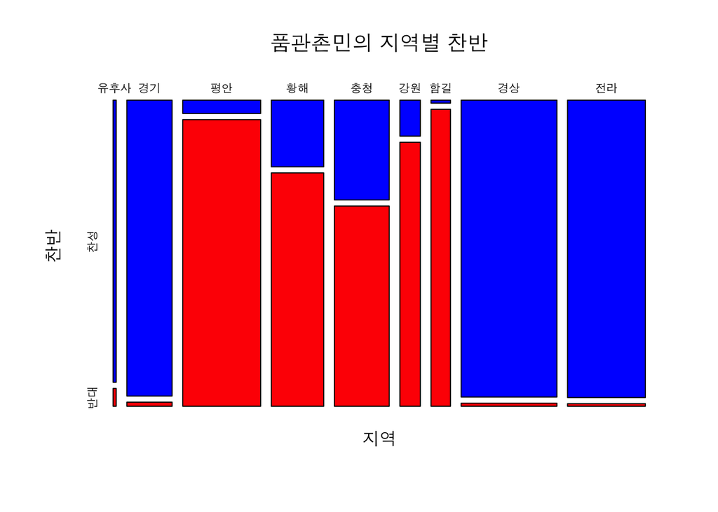

```r
mosaicplot(xtabs(counts~region+vote, data=sejong.poll.2[class.2=="품관촌민",], drop=T), col=color, main="품관촌민의 지역별 찬반", xlab="지역", ylab="찬반")
```

## 충청 지역의 여론조사결과

- 충청도는 관료들의 찬반과 품관촌민의 찬반이 다른 곳이 있으므로 따로 집계하여 분석하였다.

```r
xtabs(counts~vote+class, data=sejong.poll.2[region=="충청",], drop=T)
```

```
##       class
## vote   대신 등  수령 품관촌민
##   찬성       0    35     6982
##   반대       2    26    14013
```

```r
prop.table(xtabs(counts~vote+class, data=sejong.poll.2[region=="충청",], drop=T), margin=2)
```

```
##       class
## vote   대신 등  수령 품관촌민
##   찬성   0.000 0.574    0.333
##   반대   1.000 0.426    0.667
```

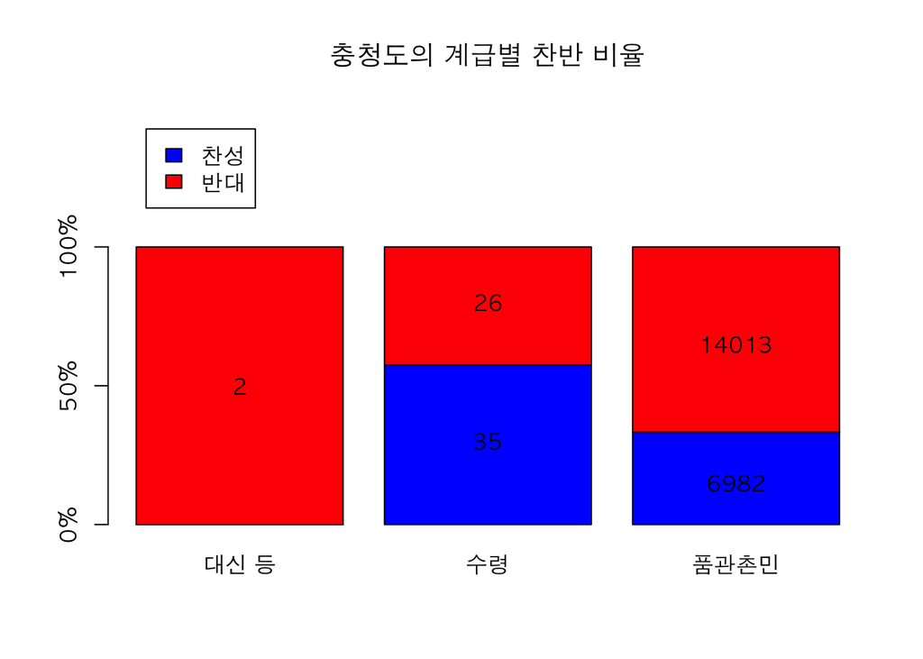

```r
barplot(prop.table(xtabs(counts~vote+class, data=sejong.poll.2[region=="충청",], drop=T), margin=2), col=color, ylim=c(0, 1.5), axes=F)
axis(side=2, at=c(0, 0.5, 1.0), labels=c("0%", "50%", "100%"))
title(main="충청도의 계급별 찬반 비율")
legend("topleft", inset=0.05, fill=c("blue", "red"), legend=c("찬성", "반대"))
text(x=c(0.7, 1.9, 1.9, 3.1, 3.1), y=c(0.5, 0.3, 0.8, 0.15, 0.65), labels=c(2, 35, 26, 6982, 14013))
```

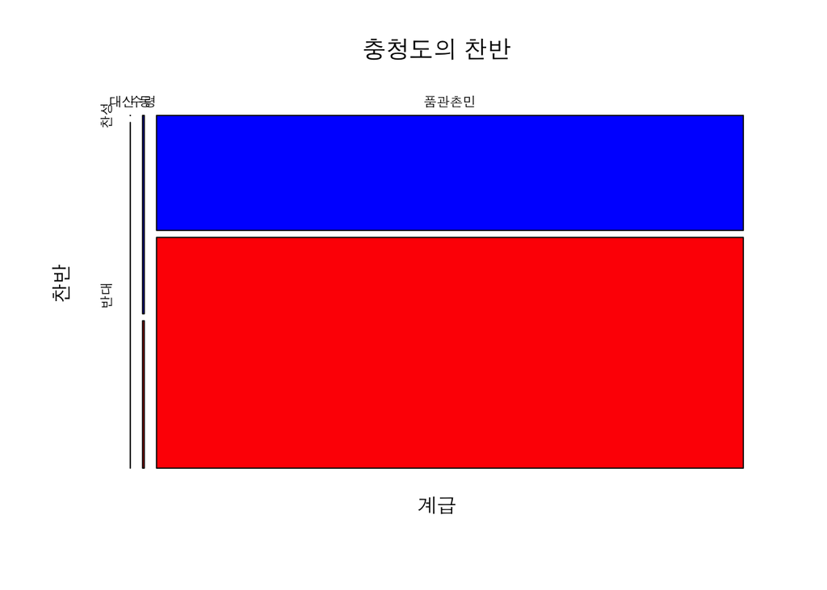

```r
mosaicplot(xtabs(counts~class+vote, data=sejong.poll.2[region=="충청",], drop=T), col=color, main="", xlab="계급", ylab="찬반")
title(main="충청도의 찬반")
```

- 작업 디렉토리의 이미지와 히스토리를 저장하고 작업을 마무리.

```r
save.image(file="sejong_poll_project.rda")
```

# GGPlot에서 해보면

```r
# install.packages("ggplot2")
library(ggplot2)
#서울지역의 여론조사
(sejong.poll.2.seoul <- subset(sejong.poll.2, region == "서울"))
```

```
##   counts vote       class region color  class.2
## 1     21 찬성     대신 등   서울  blue 관료집단
## 2    194 반대     대신 등   서울   red 관료집단
## 3    259 찬성 3품이하현직   서울  blue 관료집단
## 4    393 반대 3품이하현직   서울   red 관료집단
## 5    443 찬성 3품이하전직   서울  blue 관료집단
## 6    117 반대 3품이하전직   서울   red 관료집단
```

```r
(xtabs(counts~vote+class, data=sejong.poll.2.seoul, drop=TRUE))
```

```
##       class
## vote   대신 등 3품이하현직 3품이하전직
##   찬성      21         259         443
##   반대     194         393         117
```

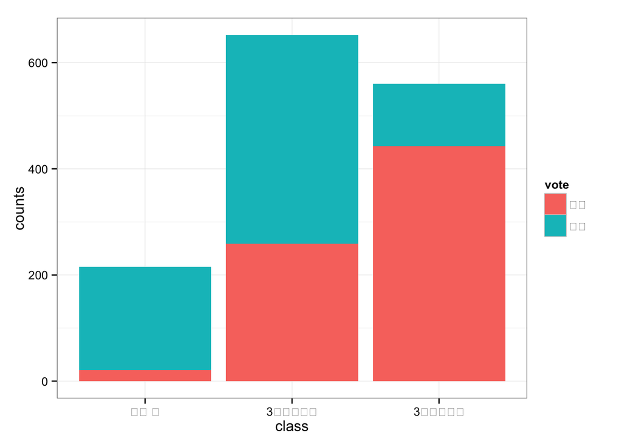

```r
(g1<-ggplot(sejong.poll.2.seoul,aes(x=class,y=counts,fill=vote))+geom_bar(stat="identity")+theme_bw())
```

```r
#서울지역을 제외한 지역의 여론조사
#(sejong.poll.2.rest<- subset(sejong.poll.2, !region=="서울"))
#(sejong.poll.2.rest)
#(xtabs(counts~vote+class, data=sejong.poll.2.rest, drop=TRUE))
#(g2<-ggplot(sejong.poll.2.rest,aes(x=region,y=counts,fill=vote))+geom_bar(stat="identity")+theme_bw())
```

```r
#서울지역을 제외한 나머지 지역의 관료집단들에대한 여론조사
(sejong.poll.2.bureaus <- subset(sejong.poll.2, class.2 == "관료집단"))
```

```
##    counts vote       class region color  class.2
## 1      21 찬성     대신 등   서울  blue 관료집단
## 2     194 반대     대신 등   서울   red 관료집단
## 3     259 찬성 3품이하현직   서울  blue 관료집단
## 4     393 반대 3품이하현직   서울   red 관료집단
## 5     443 찬성 3품이하전직   서울  blue 관료집단
## 6     117 반대 3품이하전직   서울   red 관료집단
## 9      29 찬성        수령   경기  blue 관료집단
## 10      5 반대        수령   경기   red 관료집단
## 13      1 반대     대신 등   평안   red 관료집단
## 14      6 찬성        수령   평안  blue 관료집단
## 15     35 반대        수령   평안   red 관료집단
## 18     17 찬성        수령   황해  blue 관료집단
## 19     17 반대        수령   황해   red 관료집단
## 22      2 반대     대신 등   충청   red 관료집단
## 23     35 찬성        수령   충청  blue 관료집단
## 24     26 반대        수령   충청   red 관료집단
## 27      5 찬성        수령   강원  blue 관료집단
## 28     10 반대        수령   강원   red 관료집단
## 31      1 반대     대신 등   함길   red 관료집단
## 32      3 찬성        수령   함길  blue 관료집단
## 33     14 반대        수령   함길   red 관료집단
## 36     55 찬성        수령   경상  blue 관료집단
## 37     16 반대        수령   경상   red 관료집단
## 40      2 반대     대신 등   전라   red 관료집단
## 41     42 찬성        수령   전라  blue 관료집단
## 42     12 반대        수령   전라   red 관료집단
```

```r
(bureaus.region <- subset(sejong.poll.2.bureaus, !region=="서울"))
```

```
##    counts vote   class region color  class.2
## 9      29 찬성    수령   경기  blue 관료집단
## 10      5 반대    수령   경기   red 관료집단
## 13      1 반대 대신 등   평안   red 관료집단
## 14      6 찬성    수령   평안  blue 관료집단
## 15     35 반대    수령   평안   red 관료집단
## 18     17 찬성    수령   황해  blue 관료집단
## 19     17 반대    수령   황해   red 관료집단
## 22      2 반대 대신 등   충청   red 관료집단
## 23     35 찬성    수령   충청  blue 관료집단
## 24     26 반대    수령   충청   red 관료집단
## 27      5 찬성    수령   강원  blue 관료집단
## 28     10 반대    수령   강원   red 관료집단
## 31      1 반대 대신 등   함길   red 관료집단
## 32      3 찬성    수령   함길  blue 관료집단
## 33     14 반대    수령   함길   red 관료집단
## 36     55 찬성    수령   경상  blue 관료집단
## 37     16 반대    수령   경상   red 관료집단
## 40      2 반대 대신 등   전라   red 관료집단
## 41     42 찬성    수령   전라  blue 관료집단
## 42     12 반대    수령   전라   red 관료집단
```

```r
(bureaus.region.tbl <- xtabs(counts ~ vote + region, data = bureaus.region, drop = TRUE))
```

```
##       region
## vote   경기 평안 황해 충청 강원 함길 경상 전라
##   찬성   29    6   17   35    5    3   55   42
##   반대    5   36   17   28   10   15   16   14
```

```r
(bureaus.region.df <- as.data.frame(bureaus.region.tbl))
```

```
##    vote region Freq
## 1  찬성   경기   29
## 2  반대   경기    5
## 3  찬성   평안    6
## 4  반대   평안   36
## 5  찬성   황해   17
## 6  반대   황해   17
## 7  찬성   충청   35
## 8  반대   충청   28
## 9  찬성   강원    5
## 10 반대   강원   10
## 11 찬성   함길    3
## 12 반대   함길   15
## 13 찬성   경상   55
## 14 반대   경상   16
## 15 찬성   전라   42
## 16 반대   전라   14
```

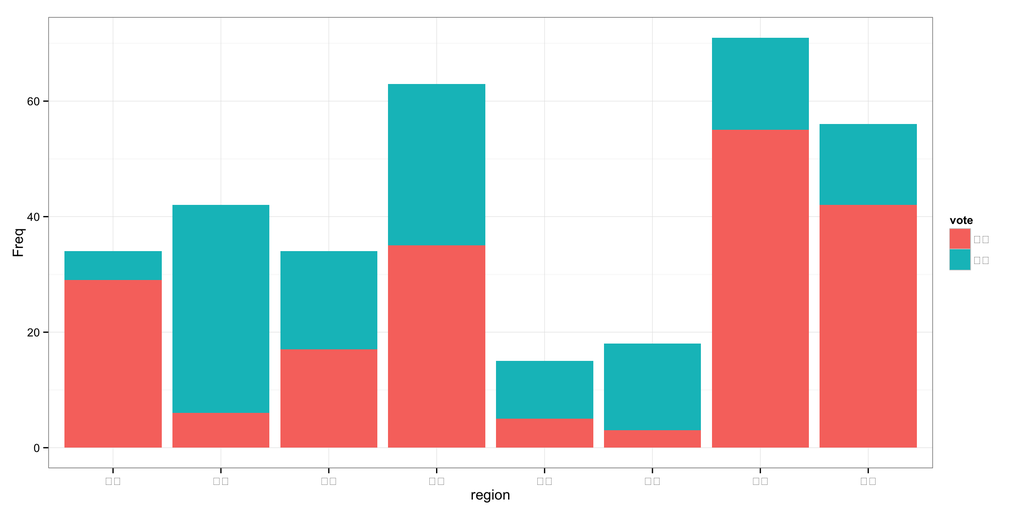

```r
(g3<-ggplot(bureaus.region.df, aes(x=region, y=Freq, fill=vote)) +geom_bar(stat="identity")+theme_bw())
```

```r
#서울지역을 제외한 나머지 지역의 품관촌민들에대한 여론조사
(sejong.poll.2.commons <- subset(sejong.poll.2, class.2 == "품관촌민"))
```

```
##    counts vote    class region color  class.2
## 7    1123 찬성 품관촌민 유후사  blue 품관촌민
## 8      71 반대 품관촌민 유후사   red 품관촌민
## 11  17076 찬성 품관촌민   경기  blue 품관촌민
## 12    236 반대 품관촌민   경기   red 품관촌민
## 16   1326 찬성 품관촌민   평안  blue 품관촌민
## 17  28474 반대 품관촌민   평안   red 품관촌민
## 20   4454 찬성 품관촌민   황해  blue 품관촌민
## 21  15601 반대 품관촌민   황해   red 품관촌민
## 25   6982 찬성 품관촌민   충청  blue 품관촌민
## 26  14013 반대 품관촌민   충청   red 품관촌민
## 29    939 찬성 품관촌민   강원  blue 품관촌민
## 30   6888 반대 품관촌민   강원   red 품관촌민
## 34     75 찬성 품관촌민   함길  blue 품관촌민
## 35   7387 반대 품관촌민   함길   red 품관촌민
## 38  36262 찬성 품관촌민   경상  blue 품관촌민
## 39    377 반대 품관촌민   경상   red 품관촌민
## 43  29505 찬성 품관촌민   전라  blue 품관촌민
## 44    257 반대 품관촌민   전라   red 품관촌민
```

```r
(commons.region <- subset(sejong.poll.2.commons, !region=="서울"))
```

```
##    counts vote    class region color  class.2
## 7    1123 찬성 품관촌민 유후사  blue 품관촌민
## 8      71 반대 품관촌민 유후사   red 품관촌민
## 11  17076 찬성 품관촌민   경기  blue 품관촌민
## 12    236 반대 품관촌민   경기   red 품관촌민
## 16   1326 찬성 품관촌민   평안  blue 품관촌민
## 17  28474 반대 품관촌민   평안   red 품관촌민
## 20   4454 찬성 품관촌민   황해  blue 품관촌민
## 21  15601 반대 품관촌민   황해   red 품관촌민
## 25   6982 찬성 품관촌민   충청  blue 품관촌민
## 26  14013 반대 품관촌민   충청   red 품관촌민
## 29    939 찬성 품관촌민   강원  blue 품관촌민
## 30   6888 반대 품관촌민   강원   red 품관촌민
## 34     75 찬성 품관촌민   함길  blue 품관촌민
## 35   7387 반대 품관촌민   함길   red 품관촌민
## 38  36262 찬성 품관촌민   경상  blue 품관촌민
## 39    377 반대 품관촌민   경상   red 품관촌민
## 43  29505 찬성 품관촌민   전라  blue 품관촌민
## 44    257 반대 품관촌민   전라   red 품관촌민
```

```r
(commons.region.tbl<- xtabs(counts~vote+region, data=commons.region, drop=TRUE))
```

```
##       region
## vote   유후사  경기  평안  황해  충청  강원  함길  경상  전라
##   찬성   1123 17076  1326  4454  6982   939    75 36262 29505
##   반대     71   236 28474 15601 14013  6888  7387   377   257
```

```r
(commons.region.df<- as.data.frame(commons.region.tbl))
```

```
##    vote region  Freq
## 1  찬성 유후사  1123
## 2  반대 유후사    71
## 3  찬성   경기 17076
## 4  반대   경기   236
## 5  찬성   평안  1326
## 6  반대   평안 28474
## 7  찬성   황해  4454
## 8  반대   황해 15601
## 9  찬성   충청  6982
## 10 반대   충청 14013
## 11 찬성   강원   939
## 12 반대   강원  6888
## 13 찬성   함길    75
## 14 반대   함길  7387
## 15 찬성   경상 36262
## 16 반대   경상   377
## 17 찬성   전라 29505
## 18 반대   전라   257
```

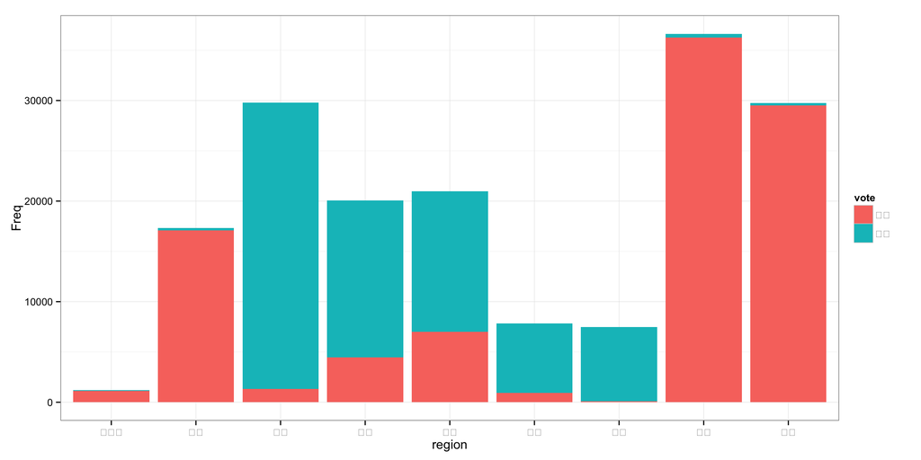

```r
(g4<-ggplot(commons.region.df,aes(x=region, y=Freq, fill=vote))+geom_bar(stat="identity")+theme_bw())
```

```r
#충청지역의 여론조사 결과
(sejong.poll.2.cc<-subset(sejong.poll.2,region=="충청"))
```

```
##    counts vote    class region color  class.2
## 22      2 반대  대신 등   충청   red 관료집단
## 23     35 찬성     수령   충청  blue 관료집단
## 24     26 반대     수령   충청   red 관료집단
## 25   6982 찬성 품관촌민   충청  blue 품관촌민
## 26  14013 반대 품관촌민   충청   red 품관촌민
```

```r
(sejong.cc<-prop.table(xtabs(counts~vote+class, data=sejong.poll.2.cc, drop=TRUE),margin=2))
```

```
##       class
## vote   대신 등  수령 품관촌민
##   찬성   0.000 0.574    0.333
##   반대   1.000 0.426    0.667
```

```r
(sejong.cc.df <- as.data.frame(sejong.cc))
```

```
##   vote    class  Freq
## 1 찬성  대신 등 0.000
## 2 반대  대신 등 1.000
## 3 찬성     수령 0.574
## 4 반대     수령 0.426
## 5 찬성 품관촌민 0.333
## 6 반대 품관촌민 0.667
```

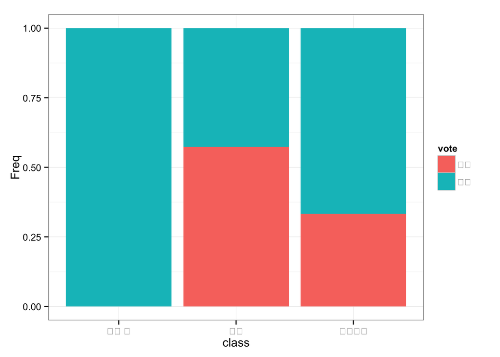

```r
(g5<-ggplot(sejong.cc.df,aes(x=class,y=Freq,fill=vote))+geom_bar(stat="identity")+theme_bw())
```

```r
# source("K:/Project./theme_kr.R")
source("./theme_kr.R")
ls()
```

```
##  [1] "bureaus.region"        "bureaus.region.df"
##  [3] "bureaus.region.tbl"    "commons.region"
##  [5] "commons.region.df"     "commons.region.tbl"
##  [7] "g1"                    "g3"
##  [9] "g4"                    "g5"
## [11] "sejong.cc"             "sejong.cc.df"
## [13] "sejong.poll"           "sejong.poll.2"
## [15] "sejong.poll.2.bureaus" "sejong.poll.2.cc"
## [17] "sejong.poll.2.commons" "sejong.poll.2.seoul"
## [19] "theme.kr"
```

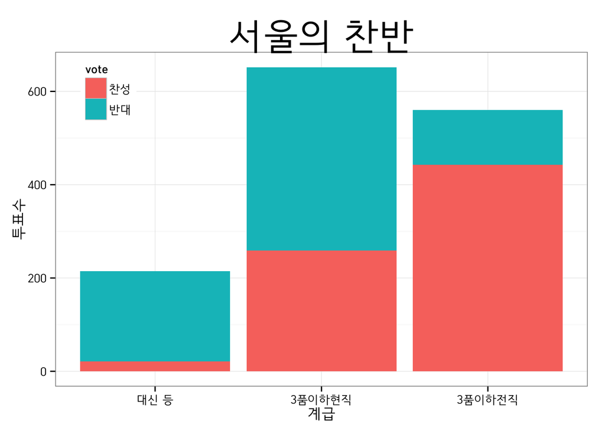

```r
(g1.1<-g1+theme.kr+xlab("계급")+ylab("투표수")+ggtitle("서울의 찬반")+theme(plot.title=element_text(size=30),legend.position=c(0.1,0.88)))
```

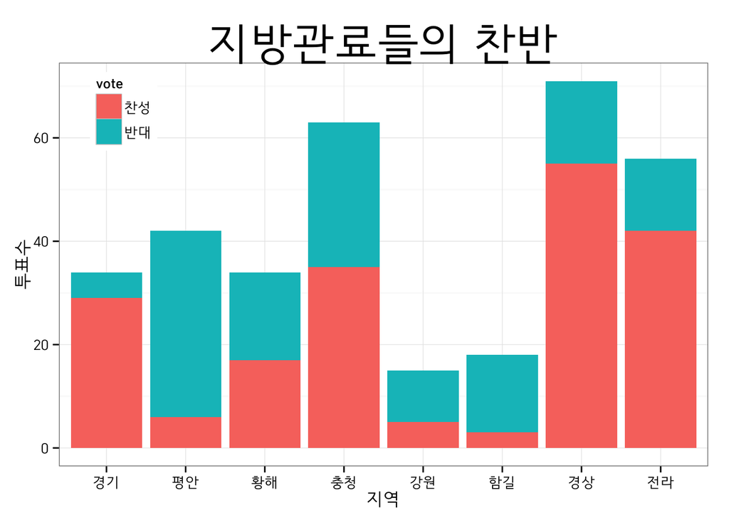

```r
#(g2.2<-g2+theme.kr+xlab("지역")+ylab("투표수")+ggtitle("서울지역을 제외한 지역의 찬반")+theme(plot.title=element_text(size=30),legend.position=c(0.1,0.88)))

(g3.3<-g3+theme.kr+xlab("지역")+ylab("투표수")+ggtitle("지방관료들의 찬반")+theme(plot.title=element_text(size=30),legend.position=c(0.1,0.88)))
```

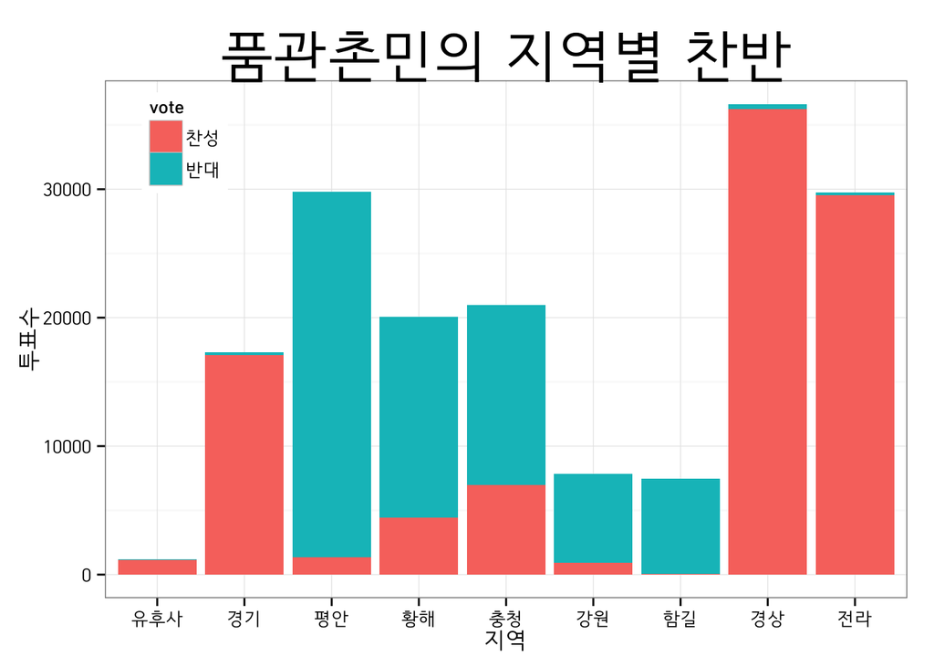

```r
(g4.4<-g4+theme.kr+xlab("지역")+ylab("투표수")+ggtitle("품관촌민의 지역별 찬반")+theme(plot.title=element_text(size=30),legend.position=c(0.1,0.88)))
```

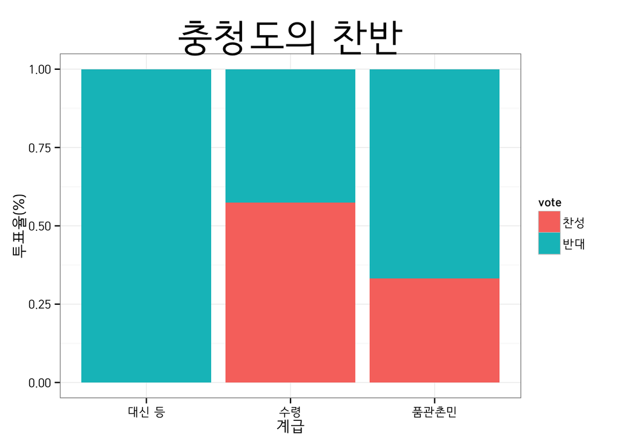

```r
(g5.5<-g5+theme.kr+xlab("계급")+ylab("투표율(%)")+ggtitle("충청도의 찬반")+theme(plot.title=element_text(size=30)))
```

# 연도별 호수 및 인구

```r
sejong.number<-read.table("./population_utf8.txt", encoding = "UTF-8", header = TRUE, sep = "")
sejong.number
```

```
##    연도    호수    인구
## 1  1404  153403  322746
## 2  1406  180246  370365
## 3  1432  201853  692475
## 4  1648  441321 1531365
## 5  1657  658771 2290083
## 6  1669 1313453 5018644
## 7  1672 1178144 4701359
## 8  1678 1342428 5246972
## 9  1717 1560561 6846568
## 10 1724 1572086 6865286
## 11 1726 1576598 7032425
## 12 1777 1715371 7238546
```

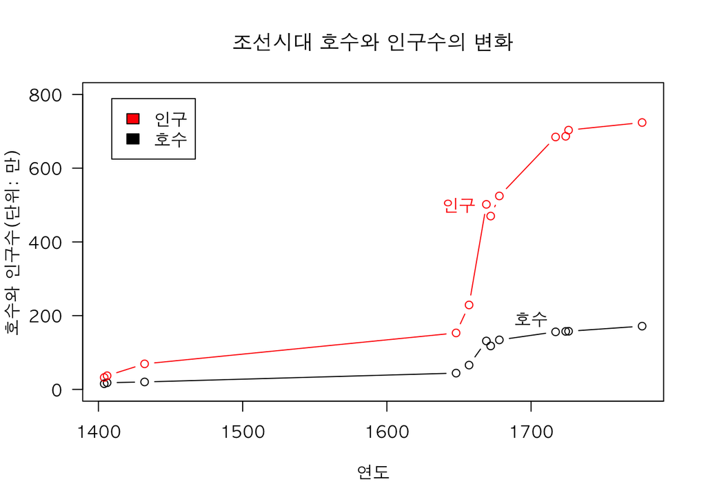

```r
plot(x=sejong.number$"연도", y=sejong.number$"호수",type="b",ann=F, xaxt="n",yaxt="n",ylim=c(0,8000000))
lines(x=sejong.number$"연도", y=sejong.number$"인구", type="b",col="red")
axis(side=1, at=seq(1400,1800,by=100),labels=seq(1400,1800, by=100))
axis(side=2, at=seq(0,8000000,by=2000000),labels=seq(0,800,by=200),las=1)
title(main="조선시대 호수와 인구수의 변화",xlab="연도",ylab="호수와 인구수(단위: 만)")
text(x=c(1650,1700),y=c(5000000,1900000), labels=c("인구","호수"),col=c("red","black"))
legend("topleft",inset=0.05,fill=c("red","black"),legend=c("인구","호수"))
```